# Part 2

## Model Comparison

### Step 12

long.landing

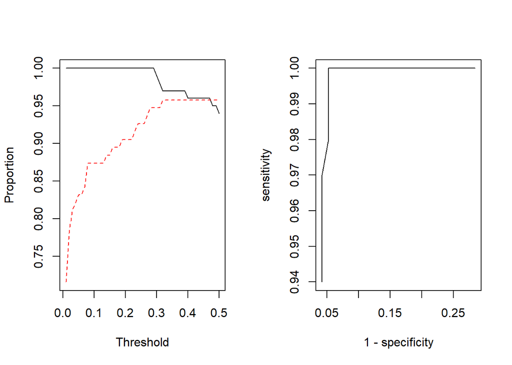

```r
thresh <- seq(0.01,0.5,0.01)
predprob <- predict(model_aic, type = "response")
predprob_risky <- predict(model_aic_risky, type = "response")
long.landing_na <- long.landing[!is.na(filtered_2$speed_air) & !is.na(filtered_2$duration)]

sensitivity <- specificity<-rep(NA,length(thresh))

for(j in seq(along=thresh)) {
  pp<-ifelse(predprob < thresh[j], "no", "yes")
  xx<-xtabs(~long.landing_na + pp, filtered_2)
  specificity[j] <- xx[1,1]/(xx[1,1] + xx[1,2])
  sensitivity[j] <- xx[2,2]/(xx[2,1] + xx[2,2])
}

par(mfrow= c(1,2))
matplot(thresh,cbind(sensitivity, specificity), type="l", xlab="Threshold", ylab="Proportion", lty=1:2)
plot(1-specificity, sensitivity, type="l");abline(0, 1, lty=2)
```

Risky.landing

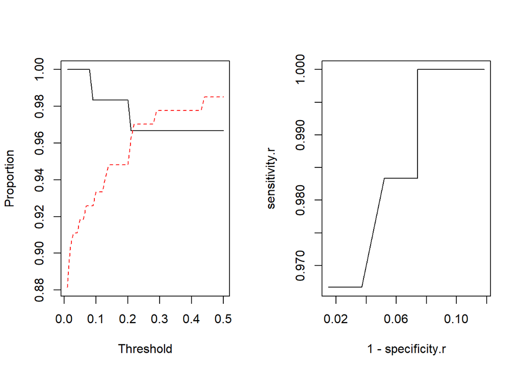

```r
thresh <- seq(0.01, 0.5, 0.01)
predprob <- predict(model_aic, type = "response")
predprob_risky <- predict(model_aic_risky, type = "response")
risky.landing_na <- risky.landing[!is.na(filtered_2$speed_air) & !is.na(filtered_2$duration)]

sensitivity.r <- specificity.r <- rep(NA,length(thresh))

for(j in seq(along=thresh)) {
  pp <- ifelse(predprob_risky < thresh[j], "no", "yes")
  xx <- xtabs(~risky.landing_na + pp, filtered_2)
  specificity.r[j] <- xx[1, 1]/(xx[1, 1] + xx[1, 2])
  sensitivity.r[j] <- xx[2, 2]/(xx[2, 1] + xx[2, 2])
}
par(mfrow=c(1,2))
matplot(thresh,cbind(sensitivity.r,specificity.r),type="l",xlab="Threshold",ylab="Proportion",lty=1:2)
plot(1-specificity.r,sensitivity.r,type="l");abline(0,1,lty=2)
```

There seems to be a relationship between the two plots, as when one increases, the other decreases.

### Step 13

```r
ilogit <- function (x) {
  exp(x)/(1+exp(x))
}
new_ind_risky<-data.frame(aircraft=2, duration=200, no_pasg=80, speed_ground=115, speed_air=120, height=40, pitch=4)
```

Predicted probability for risky landing

```r
predict(full_model_2,newdata=new_ind_risky,type="link",se=T)
```

```
## $fit
##        1
## 8.463332
##
## $se.fit
## [1] 2.089366
##
## $residual.scale
## [1] 1
```

```r
round(ilogit(c(8.463332-1.96*2.089367,8.463332+1.96*2.089367)),3)
```

```
## [1] 0.987 1.000
```

Long Landing

```r
new_ind_long<-data.frame(aircraft=1, duration=200, no_pasg=80, speed_ground=115, speed_air=120, height=40, pitch=4)
```

Predicted probability for long landing

```r
predict(full_model,newdata=new_ind_long,type="link",se=T)
```

```
## $fit
##        1
## 7.026765
##
## $se.fit
## [1] 1.211391
##
## $residual.scale
## [1] 1
```

```r
round(ilogit(c(7.026765-1.96*1.211391,7.026765+1.96*1.211391)),3)
```

```
## [1] 0.991 1.000
```

## Different link functions

### Step 14

```r
risky_logit <- glm(risky.landing ~ aircraft + speed_ground, data = filtered_2, family = binomial(link = logit))

risky_probit <- glm(risky.landing ~ aircraft + speed_ground, data = filtered_2, family = binomial(link = probit))

risky_cloglog<-glm(risky.landing ~  speed_ground + aircraft,family=binomial(link=cloglog),filtered_2)

risky_cloglog_summary <- summary(risky_cloglog)
risky_cloglog_summary
```

```
##
## Call:
## glm(formula = risky.landing ~ speed_ground + aircraft, family = binomial(link = cloglog),
##     data = filtered_2)
##
## Deviance Residuals:
##      Min        1Q    Median        3Q       Max
## -2.24103  -0.00182  -0.00004   0.00000   1.67963
##
## Coefficients:
##              Estimate Std. Error z value Pr(>|z|)
## (Intercept)  -72.1639    15.3685  -4.696 2.66e-06 ***
## speed_ground   0.6221     0.1326   4.690 2.74e-06 ***
## aircraft       2.8984     0.8002   3.622 0.000292 ***
## ---
## Signif. codes:  0 '***' 0.001 '**' 0.01 '*' 0.05 '.' 0.1 ' ' 1
##
## (Dispersion parameter for binomial family taken to be 1)
##
##     Null deviance: 436.195  on 831  degrees of freedom
## Residual deviance:  41.443  on 829  degrees of freedom
## AIC: 47.443
##
## Number of Fisher Scoring iterations: 13
```

```r
risky_logit_summary <- summary(risky_logit)
risky_logit_summary
```

```
##
## Call:
## glm(formula = risky.landing ~ aircraft + speed_ground, family = binomial(link = logit),
##     data = filtered_2)
##
## Deviance Residuals:
##      Min        1Q    Median        3Q       Max
## -2.24398  -0.00011   0.00000   0.00000   1.61021
##
## Coefficients:
##               Estimate Std. Error z value Pr(>|z|)
## (Intercept)  -106.0963    25.7459  -4.121 3.77e-05 ***
## aircraft        4.0190     1.2494   3.217   0.0013 **
## speed_ground    0.9263     0.2248   4.121 3.78e-05 ***
## ---
## Signif. codes:  0 '***' 0.001 '**' 0.01 '*' 0.05 '.' 0.1 ' ' 1
##
## (Dispersion parameter for binomial family taken to be 1)
##
##     Null deviance: 436.195  on 831  degrees of freedom
## Residual deviance:  40.097  on 829  degrees of freedom
## AIC: 46.097
##
## Number of Fisher Scoring iterations: 12
```

```r
risky_prohibit_summary <- risky_probit
risky_prohibit_summary
```

```
##
## Call:  glm(formula = risky.landing ~ aircraft + speed_ground, family = binomial(link = probit),
##     data = filtered_2)
##
## Coefficients:
##  (Intercept)      aircraft  speed_ground
##     -61.0498        2.3567        0.5322
##
## Degrees of Freedom: 831 Total (i.e. Null);  829 Residual
## Null Deviance:       436.2
## Residual Deviance: 39.44     AIC: 45.44
```

```r
round(coefficients(risky_logit_summary),4)
```

```
##               Estimate Std. Error z value Pr(>|z|)
## (Intercept)  -106.0963    25.7459 -4.1209   0.0000
## aircraft        4.0190     1.2494  3.2168   0.0013
## speed_ground    0.9263     0.2248  4.1206   0.0000
```

```r
round(coefficients(risky_prohibit_summary),4)
```

```
##  (Intercept)     aircraft speed_ground
##     -61.0498       2.3567       0.5322
```

```r
round(coefficients(risky_cloglog_summary),4)
```

```
##              Estimate Std. Error z value Pr(>|z|)
## (Intercept)  -72.1639    15.3685 -4.6956    0e+00
## speed_ground   0.6221     0.1326  4.6898    0e+00
## aircraft       2.8984     0.8002  3.6221    3e-04
```

The logit model coefficients seem to be nearly double of prohibit. The null deviance is nearly identical in all three models.

### Step 15

```r
pred_logit <- predict(risky_logit, type = "response")
pred_probit <- predict(risky_probit, type = "response")
pred_cloglog <- predict(risky_cloglog, type = "response")
```

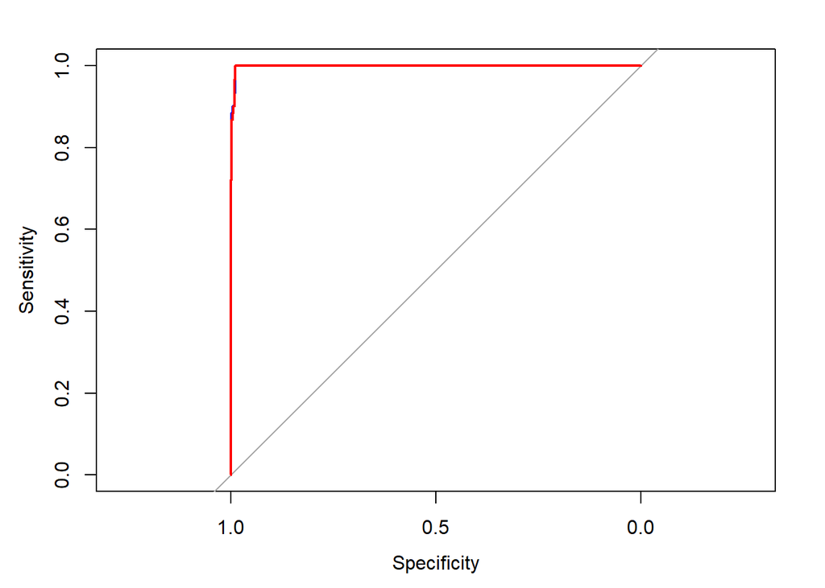

```r
ROC_logit <- roc(filtered_2$risky.landing, pred_logit)
ROC_probit <- roc(filtered_2$risky.landing, pred_probit)
ROC_cloglog <- roc(filtered_2$risky.landing, pred_cloglog)

plot(ROC_logit)
lines(ROC_probit, col= 'blue')
lines(ROC_cloglog, col= "red")
```

All three ROC curves are very closely overlapping, thus making it hard to differentiate.

### Step 16

```r
logit_index <- sort(as.numeric(names(tail(sort(pred_logit), 5))))
logit_sort <- filtered_2[logit_index,1:7]
logit_sort
```

```
##     aircraft  duration no_pasg speed_ground speed_air   height    pitch
## 64         2 161.89247      72     129.2649  128.4177 33.94900 4.139951
## 307        2 154.52460      67     129.3072  127.5933 23.97850 5.154699
## 362        2  63.32952      52     132.7847  132.9115 18.17703 4.110664
## 387        2 153.83445      61     126.8393  126.1186 20.54783 4.334558
## 408        1 131.73110      60     131.0352  131.3379 28.27797 3.660194
```

```r
prohibit_index <-sort(as.numeric(names(tail(sort(pred_probit),5))))
prohibit_sort <- filtered_2[prohibit_index,1:7]
prohibit_sort
```

```
##     aircraft  duration no_pasg speed_ground speed_air   height    pitch
## 362        2  63.32952      52     132.7847  132.9115 18.17703 4.110664
## 383        2  99.68150      61     121.8371  120.9534 33.18460 3.867476
## 387        2 153.83445      61     126.8393  126.1186 20.54783 4.334558
## 408        1 131.73110      60     131.0352  131.3379 28.27797 3.660194
## 643        1 137.58573      66     126.2443  127.9371 35.17570 2.701924
```

```r
cloglog_index <- sort(as.numeric(names(tail(sort(pred_cloglog), 5))))
cloglog_sort <- filtered_2[cloglog_index,1:7]
cloglog_sort
```

```
##     aircraft  duration no_pasg speed_ground speed_air   height    pitch
## 643        1 137.58573      66     126.2443  127.9371 35.17570 2.701924
## 669        1 140.45311      75     120.4189  118.4847 31.26345 2.796731
## 751        1 175.51443      49     125.2123  125.1385 22.52478 4.365772
## 765        1 220.05713      61     120.5579  118.2882 15.66566 4.111265
## 769        1  98.50031      66     123.3105  124.3908 22.32718 4.276710
```

```r
risky.df <- cbind(logit_index,prohibit_index,cloglog_index)
colnames(risky.df)<- c("Logit","Prohibit","Cloglog")
risky.df
```

```
##      Logit Prohibit Cloglog
## [1,]    64      362     643
## [2,]   307      383     669
## [3,]   362      387     751
## [4,]   387      408     765
## [5,]   408      643     769
```

In logit and prohibit, 362, 387, and 408 share commmon values. In prohibit and cloglog, 643 is the only value.

### Step 17

```r
predict(risky_logit,newdata = new_ind_risky,type = "link",se=T)
```

```
## $fit
##        1
## 8.463332
##
## $se.fit
## [1] 2.089366
##
## $residual.scale
## [1] 1
```

```r
round(ilogit(c(8.463332-1.96*2.089366,8.463332+1.96*2.089366)),3)
```

```
## [1] 0.987 1.000
```

```r
predict(risky_probit,newdata = new_ind_risky,type = "link",se=T)
```

```
## $fit
##        1
## 4.872041
##
## $se.fit
## [1] 1.127891
##
## $residual.scale
## [1] 1
```

```r
round(ilogit(c(4.872041-1.96*1.127891,4.872041+1.96*1.27891)),3)
```

```
## [1] 0.935 0.999
```

```r
predict(risky_cloglog,newdata = new_ind_risky,type = "link",se=T)
```

```
## $fit
##       1
## 5.16944
##
## $se.fit
## [1] 1.173423
##
## $residual.scale
## [1] 1
```

```r
round(ilogit(c(5.16944-1.96*1.173423,5.16944+1.96*1.173423)),3)
```

```
## [1] 0.946 0.999
```

Logit has the same confidence interval, while prohibit and cloglog are 0.935 and 0.946 instead of 0.987.